# Visualização de dados - Curso-R

- Mostrar o código
- Esconder o código
- Ver o código fonte

Trabalho final

Autor

Afiliação

João Gabriel Leal

ENSP - Fiocruz

Data de Publicação

01/05/2023

**Código**

```r
#| echo: false

# 1. Abrir pacotes

pacman::p_load(tidyverse, readr, readxl,patchwork, textclean)

# 2. Abrir bancos

## Polio (Pol3) immunization coverage among 1-year-olds (%)
polio <- read_csv("~/treinamento_rstudio/curso_r_visualizacao_grafico_2023/trabalho_final/2811fc24-c3ac-4c51-816c-24b678c51764.csv")

## BCG immunization coverage among 1-year-olds (%)
bcg <- read_csv("~/treinamento_rstudio/curso_r_visualizacao_grafico_2023/trabalho_final/858dc50d-65e9-4d97-8ea6-268b46d4a8ab.csv")

## Banco tubeculose (data-sus)
turbe_casos <- read.csv("~/treinamento_rstudio/curso_r_visualizacao_grafico_2023/trabalho_final/A104430189_28_143_208_certo.csv", sep=";")

## Banco cobertura Bcg (WHO)
bcg <- read_csv("~/treinamento_rstudio/curso_r_visualizacao_grafico_2023/trabalho_final/858dc50d-65e9-4d97-8ea6-268b46d4a8ab.csv")


# 3. Definir o tema dos gráficos

tema <- ggthemes::theme_fivethirtyeight(base_family = "Times New Roman") +
  theme(plot.title = element_text(size = 40, margin = margin(0, 0, 30, 0)),
        axis.title.x = element_text(size = 45),
        axis.title.y = element_text(size = 38),
        axis.text.x =  element_text(size = 35),
        axis.text.y =  element_text(size = 38),
        legend.position = "bottom",
        legend.text = element_text(size = 38),
        plot.caption = element_text(hjust = 0, size = 38),
        panel.background = element_rect(fill = "white", colour = "white", color = "white"),
        plot.background = element_rect(fill = "white", colour = "white", color = "white"),
        legend.background = element_rect(fill = "white"),
        panel.grid.major.x = element_line(colour = "#f2f2f2", size = 1.5),
        panel.grid.major.y = element_line(colour = "#f2f2f2", size = 1.5),
        legend.box = "horizontal",
        legend.key = element_rect(fill = "white", color = "white"))

ggplot2::theme_set(tema)
```

# Introdução

Os líderes políticos de extrema direita chegam ao poder e manipulam a máquina estatal de acordo com o seu discurso. Jair Bolsonaro, político alinhado a esta pauta, foi porta-voz de falas contrárias à adesão da vacina de covid 19 desde do primeiro ano da pandemia.

Publicamente, o antigo líder expressava seu desdém pela ciência, criticava a segurança e a eficácia das vacinas, zombava e até associava as vacinas à propagação de doenças. As afirmações falsas de Bolsonaro podem ter influenciado no aumento da hesitação vacinal da população, não somente em relação à vacina da covid. As preocupações se expandem também para as vacinas previstas no calendário obrigatório de saúde, que previnem doenças como a poliomielite ou a tuberculose, que historicamente tinham um nível de adesão extremamente alto no país. Neste contexto, o governo cortou o orçamento para inúmeras áreas do SUS, inclusive para as vacinas, além de ter diminuído as verbas para publicidade das vacinas da gripe. O que pode parecer um governo mal estruturado e avesso a medidas orientadas pelos órgãos de saúde internacionais é, na verdade, uma manifestação concreta de um ideal de Estado e um meio de desfazer feitos de governos anteriores.

Segundo os dados do Observa Infância, que reúne pesquisadores da Fundação Oswaldo Cruz (Fiocruz) e do Centro Universitário Arthur de Sá Earp Neto (Unifase), o Brasil registrou nos últimos anos uma enorme queda da coberturas da vacina BCG em bebês de 0 a 1 ano, vacina responsável pela proteção do organismo contra a tuberculose. Em meio a esta problematização, eu pretendo analisar no gráfico a seguir se essa diminuição está, de alguma forma, relacionada com o aumento de casos de tuberculose em crianças no país. Elaborei um gráfico que mostra, nos últimos vinte um anos, a cobertura da vacina BCG em bebês de até 1 ano, e a indicação se os casos de tuberculose em crianças diminuíram ou aumentaram de um ano para o outro. Os dados sobre os casos de tuberculose foram retirados do Sistema de Informação de Agravos de Notificação (Sinan), enquanto de cobertura BCG dos acervos da organização mundial da saúde.

# Análise

Pode-se notar que, infelizmente, há em curso no país um processo de diminuição da cobertura vacinal de BCG, nossos bebês que possuíam um percentual de cobertura acima de 90% no passado, agora possuem uma abertura abaixo dos 70%.

**Código**

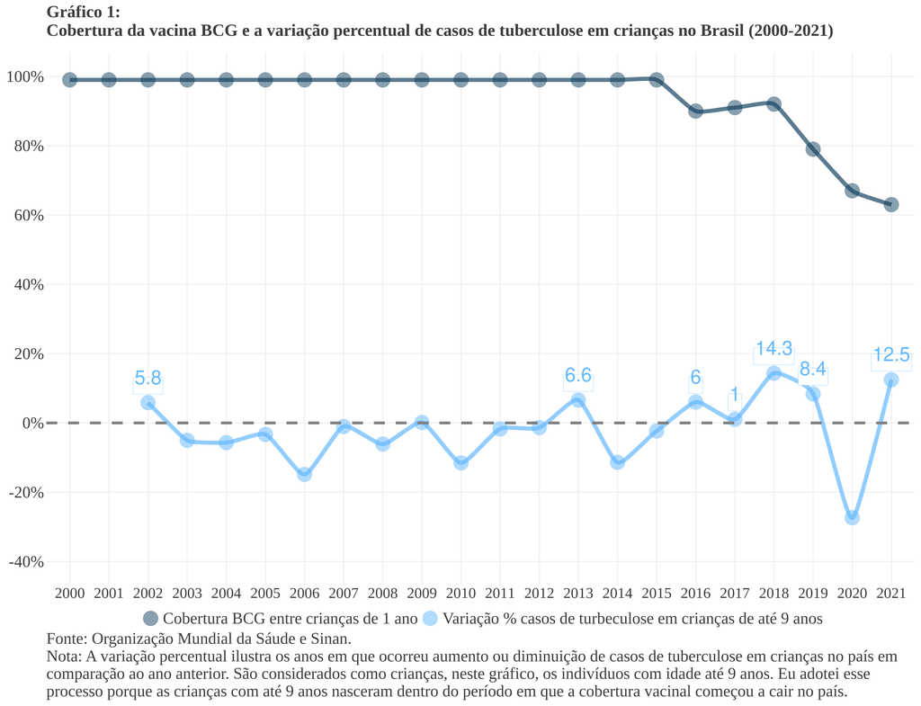

```r
# cria banco turbe_casos

turbe_casos <- turbe_casos[-23, ] # apagar linha vazia

turbe_casos <- turbe_casos %>%
  mutate(casos_tube_0_9_anos = X.1.Ano+X1.4.anos+X5.9.anos) %>% # agreguei os casos de 0 aos 9 anos
  filter(Ano != 2022) %>% # tirei o ano de 2022
  select(Ano,casos_tube_0_9_anos) # selecionei as variaveis de interesse

turbe_casos_vari <- turbe_casos %>%
  pivot_wider(names_from = Ano, values_from = casos_tube_0_9_anos) %>% # por em wide
  mutate(vari_01_02 = (round((`2002`-`2001`)/`2001` * 100,2)), # calcular variavel
         vari_02_03 = (round((`2003`-`2002`)/`2002` * 100,2)),
         vari_03_04 = (round((`2004`-`2003`)/`2003` * 100,2)),
         vari_04_05 = (round((`2005`-`2004`)/`2004` * 100,2)),
         vari_05_06 = (round((`2006`-`2005`)/`2005` * 100,2)),
         vari_06_07 = (round((`2007`-`2006`)/`2006` * 100,2)),
         vari_07_08 = (round((`2008`-`2007`)/`2007` * 100,2)),
         vari_08_09 = (round((`2009`-`2008`)/`2008` * 100,2)),
         vari_09_10 = (round((`2010`-`2009`)/`2009` * 100,2)),
         vari_10_11 = (round((`2011`-`2010`)/`2010` * 100,2)),
         vari_11_12 = (round((`2012`-`2011`)/`2011` * 100,2)),
         vari_12_13 = (round((`2013`-`2012`)/`2012` * 100,2)),
         vari_13_14 = (round((`2014`-`2013`)/`2013` * 100,2)),
         vari_14_15 = (round((`2015`-`2014`)/`2014` * 100,2)),
         vari_15_16 = (round((`2016`-`2015`)/`2015` * 100,2)),
         vari_16_17 = (round((`2017`-`2016`)/`2016` * 100,2)),
         vari_17_18 = (round((`2018`-`2017`)/`2017` * 100,2)),
         vari_18_19 = (round((`2019`-`2018`)/`2018` * 100,2)),
         vari_19_20 = (round((`2020`-`2019`)/`2019` * 100,2)),
         vari_20_21 = (round((`2021`-`2020`)/`2020` * 100,2))) %>%
  select(vari_01_02, vari_02_03, vari_03_04, vari_04_05, vari_05_06, vari_06_07, # selecionar vari calculadas
         vari_07_08, vari_08_09, vari_09_10, vari_10_11, vari_11_12, vari_12_13,
         vari_13_14, vari_14_15, vari_15_16, vari_16_17, vari_17_18, vari_18_19,
         vari_19_20, vari_20_21) %>%
  rename(`2002` = vari_01_02, `2003` = vari_02_03, `2004` = vari_03_04, # renomear variacao
         `2005` = vari_04_05, `2006` = vari_05_06, `2007` = vari_06_07,
         `2008` = vari_07_08, `2009` = vari_08_09, `2010` = vari_09_10,
         `2011` = vari_10_11, `2012` = vari_11_12, `2013` = vari_12_13,
         `2014` = vari_13_14, `2015` = vari_14_15, `2016` = vari_15_16,
         `2017` = vari_16_17, `2018` = vari_17_18, `2019` = vari_18_19,
         `2020` = vari_19_20, `2021` = vari_20_21) %>%
  mutate(long="long") %>% # variavel necessaria para por em long
  pivot_longer(!long, names_to = "ano", # tranformar em long
               values_to = "vari_casos_tube_0_9_anos") %>%
  mutate(long= NULL, # apagar variavel necessaria para por em long
         ano = as.numeric(ano))

bcg_paises <- bcg   %>%
  select( Period, Indicator,
          #ParentLocation,
          Location,
          Value
  ) %>%
  filter (Indicator == "BCG immunization coverage among 1-year-olds (%)",
          Location %in% c (
            "Brazil",
            "China",
            "Russian Federation",
            "India",
            "South Africa"),
          Period %in% c (2000:2021)) %>%
  rename(Value = Value)

bcg_brics <- bcg  %>%
  mutate(Value = as.numeric(Value),
         Location = "Brics",
         Indicator = "BCG immunization coverage among 1-year-olds (%)") %>%
  group_by(Location, Period, Indicator) %>%
  summarise(Value= round(mean(Value),2))

bcg_parents <- bcg  %>% select(
  Period,
  Indicator,
  ParentLocation,
  Location,
  Value
) %>%
  filter (!Location  %in% c("Canada", "United States of America"),
          Indicator %in% c ("BCG immunization coverage among 1-year-olds (%)")) %>%
  filter (Period %in% c (2000:2021)) %>%
  group_by(ParentLocation, Period ) %>%
  mutate(Value = as.numeric(Value)) %>%
  summarise(Value= round(mean(Value),2)) %>%
  rename(Location = ParentLocation) %>%
  mutate (#Period = "2020",
    Indicator = "BCG immunization coverage among 1-year-olds (%)")

bcg_completo <- rbind( bcg_paises, bcg_brics, bcg_parents)

bcg_brasil <- bcg_completo %>%
  filter(Location == "Brazil")

# juntar os bancos
bcg_casos_brasil  <- left_join(bcg_brasil, turbe_casos,
                               by= c("Period" =  "Ano"))

bcg_casos_brasil  <- left_join(bcg_casos_brasil, turbe_casos_vari,
                               by= c("Period" =  "ano"))



## cria ao banco

vari_casos_tube <- bcg_casos_brasil %>%
  select(Period, vari_casos_tube_0_9_anos) %>%
  rename(Value = vari_casos_tube_0_9_anos) %>%
  mutate(Indicator = "Variação % casos de turbeculose em crianças de até 9 anos")

bcg_cober_brasil <- bcg_casos_brasil %>%
  select(Period, Indicator, Value )

(bcg_turb <- rbind(vari_casos_tube, bcg_cober_brasil) %>% # juntar bancos
    mutate(Period = as.character(Period), # tranformar em caracter
           Indicator = mgsub(
             Indicator, c(
               "BCG immunization coverage among 1-year-olds (%)", # mudar noma variavel
               "Variação % casos de turbeculose em crianças de até 9 anos"),
             c(
               "Cobertura BCG entre crianças de 1 ano",
               "Variação % casos de turbeculose em crianças de até 9 anos")),
           efeitos_positivos = ifelse(  # fazer nova variavel
             Value > 0.5 &
               Indicator == "Variação % casos de turbeculose em crianças de até 9 anos",
             Value, NA)) %>%

    # Inicio do codigo para plotar o grafico

    ggplot(aes(x = Period,
               y = (Value),
               group = Indicator,
               color = Indicator))+
    ggalt::geom_xspline(aes(size = 16), alpha = .7,
      show.legend = FALSE)+ # grafico de linha curvada
    # geom_line(size = 1.5,
    #           linetype=1)+
    geom_point(size = 16, alpha = .5)+
    scale_y_continuous(labels = function(x) paste0(x, "%"),
                       limits = c(-40,100),
                       breaks = c(-40, -20, 0, 20, 40, 60, 80, 100))+
    scale_color_manual(values = c(
      "#154360",
      "steelblue1"
    ))+
    labs(x = NULL,
         y = NULL,
         col = NULL,
         linetype = NULL,
         title = "Gráfico 1:\nCobertura da vacina BCG e a variação percentual de casos de tuberculose em crianças no Brasil (2000-2021)",
         caption ="Fonte: Organização Mundial da Sáude e Sinan.\nNota: A variação percentual ilustra os anos em que ocorreu aumento ou diminuição de casos de tuberculose em crianças no país em\ncomparação ao ano anterior. São considerados como crianças, neste gráfico, os indivíduos com idade até 9 anos. Eu adotei esse\nprocesso porque as crianças com até 9 anos nasceram dentro do período em que a cobertura vacinal começou a cair no país.") +
    ggthemes::theme_fivethirtyeight()+
    tema+
    geom_hline(yintercept = 0,color="grey50",linetype=2, size = 3)+
    geom_label(
      aes(y = round(efeitos_positivos,1),
          label = round(efeitos_positivos,1)),  # forma de por o rotulo (label) para modificar com facilidade
      vjust = -0.5,
      size= 16,
      show.legend = FALSE))
```

# Conclusões

Especialistas em pediatria, infectologia, epidemiologia e saúde coletiva expressam preocupação com a possibilidade de ocorrer novas crises sanitárias no país devido à queda na vacinação. Doenças que eram comuns no passado podem ressurgir, o que é alarmante. Diante desse cenário, é importante que organizações da sociedade civil acompanhem de perto essa situação.